# Lab 1 documentation

## The Paleobiology Database

## Lab One: Exploring Table Data

### Gavin Bovone, Matthew Benedict

## https://paleobiodb.org/#/

## Business Understanding

The dataset we selected contains fossil discoveries across the world, including the type of fossil, its geologic formation, and the geographic location where it was found. These records are organized “by a multi-disciplinary, multi-institutional, international group of paleobiological researchers”. The purpose of this dataset is “to provide global, collection-based occurrence and taxonomic data for organisms of all geological ages” for which they created a public, interactive data map to educate the public on the history of life around the world.

Although the full dataset spans all kinds of fossils worldwide with over a million records, the prediction task for this project is to predict the correct age of a dinosaur fossil based on the aforementioned data collected, specifically for all of the fossils found in or around Texas. According to the American Museum of Natural History, there are many different methods to determine the estimated age of fossils, including sediment analysis. However, creating a prediction model based on geographic, sedimentary, and biological information could speed up the process of fossil dating. This is important because the age of a fossil is often difficult to determine in the field, and being able to automatically predict the time period based on the characteristics of the fossil could speed up research and improve accuracy.

### Measure of Success

Next, we have to determine what the required success of this algorithm must look like for it to be considered successful. Third parties who would be interested in these predictions include paleontologists for dating and categorizing fossils more efficiently, museums for curating accurate exhibits, and educators for developing modern teaching tools about Texas paleontology. All of these parties are focused in the scientific and educational fields, meaning they require higher standards of success. Therefore, we would want our model to at least achieve the minimum accuracy rate accepted by professionals as misclassifying a fossil’s time period could mislead scientific research and public understanding.

The research paper, [Fossil image identification using deep learning ensembles of data augmented multiviews](https://besjournals.onlinelibrary.wiley.com/doi/full/10.1111/2041-210X.14229), which is published in The British Ecological Society created a similar model based on visual data. According to the study, the expert success in this type of prediction is in the range of 63%-85%, with their model achieving a peak success rate of 87.4%. This data shows an accuracy rate of 63% is still valuable, meaning a model with slightly lower accuracy could still be valuable as a decision-support tool, helping researchers prioritize which fossils to send for further expert analysis. The visual model was able to achieve a higher rate of accuracy than professional standards, showing improvements can still be made in fossil-dating technology. Based on this, we should expect an accuracy somewhere in the range of 75%-90% so as to meet the basic scientific standards while still trying to make improvements in the field.

# Loading The Dataset

```python
# load the Titanic dataset
import pandas as pd
import numpy as np

print('Pandas:', pd.__version__)
print('Numpy:',np.__version__)

df = pd.read_csv("./pbdb_data-no-metadata.csv")
df.head()
```

```
Pandas: 2.3.2
Numpy: 2.3.2
```

|  | occurrence_no | record_type | reid_no | flags | collection_no | identified_name | identified_rank | identified_no | difference | accepted_name | ... | modifier | updater | created | modified | updated | paleomodel | geoplate | paleoage | paleolng | paleolat |
| --- | --- | --- | --- | --- | --- | --- | --- | --- | --- | --- | --- | --- | --- | --- | --- | --- | --- | --- | --- | --- | --- |
| 0 | 139341 | occ | 13412.0 | NaN | 11932 | Pleurocoelus sp. | genus | 54170 | NaN | Titanosauriformes | ... | M. Carrano | NaN | 2005-08-25 14:56:00 | 2005-08-25 16:56:00 | NaN | gplates | 101 | mid | -39.65 | 37.81 |
| 1 | 220148 | occ | NaN | NaN | 22709 | Theropoda indet. | unranked clade | 38513 | NaN | Theropoda | ... | M. Carrano | NaN | 2002-07-10 20:49:32 | 2013-10-25 16:23:05 | NaN | gplates | 101 | mid | -68.74 | 38.52 |
| 2 | 220149 | occ | 40298.0 | NaN | 22709 | Saurolophinae indet. | subfamily | 53385 | NaN | Saurolophinae | ... | NaN | NaN | 2022-12-02 16:38:06 | 2022-12-02 16:38:06 | NaN | gplates | 101 | mid | -68.74 | 38.52 |
| 3 | 220150 | occ | NaN | NaN | 22709 | Carnosauria indet. | infraorder | 53943 | NaN | Carnosauria | ... | M. Carrano | NaN | 2002-07-10 20:49:32 | 2013-10-25 16:23:05 | NaN | gplates | 101 | mid | -68.74 | 38.52 |
| 4 | 220190 | occ | 35569.0 | NaN | 22713 | Convolosaurus marri n. gen. n. sp. | species | 382687 | NaN | Convolosaurus marri | ... | NaN | NaN | 2019-03-13 10:22:26 | 2019-03-13 10:22:26 | NaN | gplates | 101 | mid | -41.71 | 35.74 |

5 rows × 91 columns

```python
# note that the describe function defaults to using only some variables
df.describe()
```

|  | occurrence_no | reid_no | collection_no | identified_no | accepted_attr | accepted_no | max_ma | min_ma | reference_no | lng | ... | regionalbedunit | regionalorder | authorizer_no | enterer_no | modifier_no | updater_no | updater | updated | paleolng | paleolat |
| --- | --- | --- | --- | --- | --- | --- | --- | --- | --- | --- | --- | --- | --- | --- | --- | --- | --- | --- | --- | --- | --- |
| count | 1.179000e+03 | 222.000000 | 1179.000000 | 1179.000000 | 0.0 | 1179.000000 | 1179.000000 | 1179.000000 | 1179.000000 | 1179.000000 | ... | 0.0 | 0.0 | 1179.000000 | 1179.000000 | 1179.000000 | 0.0 | 0.0 | 0.0 | 1080.000000 | 1080.000000 |
| mean | 9.837003e+05 | 31163.909910 | 100824.396947 | 82651.236641 | NaN | 69623.966073 | 100.072554 | 89.908984 | 44771.240882 | -102.210237 | ... | NaN | NaN | 54.431722 | 82.083121 | 41.211196 | NaN | NaN | NaN | -58.682954 | 34.061889 |
| std | 4.648948e+05 | 9695.916871 | 69245.050679 | 84005.921026 | NaN | 73224.877284 | 53.405098 | 49.739945 | 28991.261150 | 3.020217 | ... | NaN | NaN | 143.434767 | 157.989898 | 116.209117 | NaN | NaN | NaN | 14.971638 | 9.134804 |
| min | 1.393410e+05 | 12534.000000 | 3534.000000 | 36616.000000 | NaN | 36616.000000 | 0.011700 | 0.000000 | 312.000000 | -107.462601 | ... | NaN | NaN | 4.000000 | 4.000000 | 0.000000 | NaN | NaN | NaN | -104.540000 | 6.630000 |
| 25% | 5.339625e+05 | 20944.250000 | 52168.000000 | 38713.000000 | NaN | 38653.000000 | 83.600000 | 72.200000 | 15506.000000 | -103.637131 | ... | NaN | NaN | 14.000000 | 14.000000 | 0.000000 | NaN | NaN | NaN | -69.010000 | 34.570000 |
| 50% | 8.414080e+05 | 34398.500000 | 70030.000000 | 53382.000000 | NaN | 38851.000000 | 83.600000 | 72.200000 | 46717.000000 | -103.159576 | ... | NaN | NaN | 14.000000 | 14.000000 | 14.000000 | NaN | NaN | NaN | -68.140000 | 38.020000 |
| 75% | 1.436370e+06 | 40052.750000 | 170942.000000 | 91968.000000 | NaN | 64079.000000 | 113.200000 | 110.100000 | 69370.000000 | -101.162639 | ... | NaN | NaN | 14.000000 | 14.000000 | 14.000000 | NaN | NaN | NaN | -45.347500 | 38.700000 |
| max | 1.706328e+06 | 42528.000000 | 236775.000000 | 502841.000000 | NaN | 502841.000000 | 237.000000 | 227.300000 | 327912.000000 | -91.976028 | ... | NaN | NaN | 969.000000 | 1101.000000 | 969.000000 | NaN | NaN | NaN | -30.170000 | 49.210000 |

8 rows × 26 columns

```python
print(df.dtypes)
print('===========')
print(df.info())
```

```
occurrence_no      int64
record_type       object
reid_no          float64
flags             object
collection_no      int64
                  ...
paleomodel        object
geoplate          object
paleoage          object
paleolng         float64
paleolat         float64
Length: 91, dtype: object
===========
<class 'pandas.core.frame.DataFrame'>
RangeIndex: 1179 entries, 0 to 1178
```

[output cut: 97 more lines]

## Cleaning the dataset

As it is at this stage, the dataset is way too big and complicated for us to analyze in any meaningful way. There are a total of 91 columns for us to analyze, with that much data it would be very difficult for our group to be able to make any specific observations about variable importance in relation to the fossil age. In order to get a better understanding of what useful data we have available to us, we began the project with a Filter Bar Plot to try and weed out any unnecessary variables.

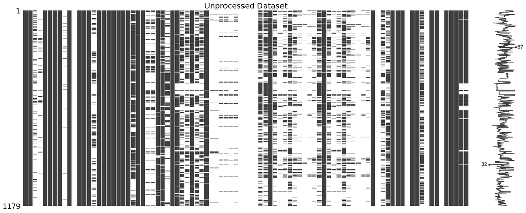

```python
import matplotlib
import matplotlib.pyplot as plt
import warnings
warnings.simplefilter('ignore', DeprecationWarning)
%matplotlib inline

# External package: conda install missingno
import missingno as mn

mn.matrix(df)
plt.title("Unprocessed Dataset",fontsize=22)

plt.figure()
plt.show()
```

Clearly, there is a lot of unusable data contained in this set. Even at a first glance, many of the columns appear completely empty and will obviously not be useful to us.

- The first step is to remove attributes that just aren't useful for us
- There are 8 columns that had no entries at all
- 14 duplicate columns
- 3 columns that only had one unique value
- 19 columns that had les than 25% of available data
- 34 identifier columns and columns with string data that was too difficult to analyze
  - columns with the word comments in it like stratcomments and geogcomments contained string data in paragraph form that we could not analyze

We also reviewed the variable we are trying to predict, fossil_age. We realized that the age was an interval value, with a minimum and maximum interval representing the different jurassic periods the fossil could have originated from, but we wanted a more precise prediction of the age. We took the average of the interval to make a new fossil_age variable, and turned the initial interval into fossil_age_error. This means we are now trying to predict an exact age of the fossil within a certain margin of error.

```
Dropped columns with no values: ['accepted_attr', 'regionalsection', 'regionalbed', 'regionalbedunit', 'regionalorder', 'updater_no', 'updater', 'updated']
Dropped duplicate columns: ['lithadj2.1', 'minor_lithology2.1', 'lithadj1.1', 'geological_group.1', 'lithology2.1', 'minor_lithology1.1', 'fossilsfrom2.1', 'lithology1.1', 'formation.1', 'lithification2.1', 'lithdescript.1', 'fossilsfrom1.1', 'member.1', 'lithification1.1']
Dropped columns with at least 75% not available: ['reid_no', 'flags', 'difference', 'altitude_value', 'altitude_unit', 'zone', 'zone_type', 'localsection', 'localbed', 'localbedunit', 'localorder', 'lithification1', 'minor_lithology1', 'lithology2', 'lithadj2', 'lithification2', 'minor_lithology2', …
Dropped columns with only 1 unique value: ['record_type', 'paleomodel', 'paleoage']
Manually selected columns to drop: ['occurrence_no', 'collection_no', 'identified_no', 'cx_int_no', 'accepted_no', 'reference_no', 'authorizer_no', 'enterer_no', 'modifier_no', 'authorizer', 'enterer', 'modifier', 'created', 'modified', 'geogcomments', 'stratcomments', 'geology_comments', 'occurrenc…
<class 'pandas.core.frame.DataFrame'>
RangeIndex: 1179 entries, 0 to 1178
Data columns (total 13 columns):
 #   Column            Non-Null Count  Dtype
---  ------            --------------  -----
 0   accepted_name     1179 non-null   object
 1   accepted_rank     1179 non-null   object
 2   lng               1179 non-null   float64
 3   lat               1179 non-null   float64
 4   geological_group  553 non-null    object
 5   member            441 non-null    object
 6   stratscale        1123 non-null   object
 7   lithology1        750 non-null    object
 8   environment       1179 non-null   object
 9   paleolng          1080 non-null   float64
 10  paleolat          1080 non-null   float64
 11  fossil_age        1179 non-null   float64
 12  fossil_age_error  1179 non-null   float64
dtypes: float64(6), object(7)
memory usage: 119.9+ KB
```

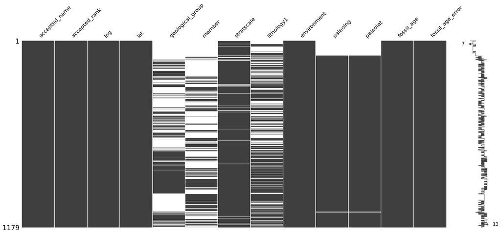

```python
def getCol(df, index): return df.iloc[:, index]
def getColName(df, index): return df.columns.values[index]
def getNumRows(df): return df.shape[0]
def getNumCols(df): return df.shape[1]
def getDuplicateCols(df):
    ret = set()
    numCols = getNumCols(df)
    for i in range(numCols):
        col = getCol(df, i)
        for j in range(i + 1, numCols):
            otherCol = getCol(df, j)
            if col.equals(otherCol):
                colName = getColName(df, i)
                otherColName = getColName(df, j)
                #print("Found duplicate pair:", colName, otherColName)
                ret.add(otherColName)
    return list(ret)

def getMissingCols(df, proportion):
    return [col for col in df.columns if df[col].count() <= (proportion * getNumRows(df))]

def uniqueCols(df, maxUniqueVals):
    return [col for col in df.columns if len(df[col].unique()) <= maxUniqueVals]

if getNumCols(df) < 91:
    print("We dropped columns already")
else:
    nullCols = getMissingCols(df, 0)
    print("Dropped columns with no values:", nullCols)
    df.drop(columns=nullCols, inplace=True)

    duplicates = getDuplicateCols(df)
    print("Dropped duplicate columns:", duplicates)
    df.drop(columns=duplicates, inplace=True)

    missingCols = getMissingCols(df, 0.25)
    print("Dropped columns with at least 75% not available:", missingCols)
    df.drop(columns=missingCols, inplace=True)

    uniques = uniqueCols(df, 1)
    print("Dropped columns with only 1 unique value:", uniques)
    df.drop(columns=uniques, inplace=True)

    # Normalization
    df['fossil_age'] = (df['max_ma'] + df['min_ma']) / 2
    df['fossil_age_error'] = (df['max_ma'] - df['min_ma']) / 2
    df.drop(columns=['min_ma', 'max_ma'], inplace=True)

    #df['altitude_meters'] = np.where(df['altitude_unit'] == 'feet',
    #    0.3048 * df['altitude_value'], df['altitude_value'])
    #df.drop(columns=['altitude_value', 'altitude_unit'], inplace=True)

    df['lithology1'] = np.where(df['lithology1'] == 'not reported', np.nan, df['lithology1'])

    manual_drop = [
        # Identifiers only
        'occurrence_no', 'collection_no', 'identified_no', 'cx_int_no',
        'accepted_no', 'reference_no', 'authorizer_no', 'enterer_no', 'modifier_no',
        'authorizer', 'enterer', 'modifier', 'created', 'modified',
        # Cannot be analyzed for our purposes
        'geogcomments', 'stratcomments', 'geology_comments', 'occurrence_comments',
        'lithdescript', 'protected', 'geoplate', 'lithadj1',
        # These fields were better represented by another field
        'early_interval', 'late_interval', 'latlng_basis', 'latlng_precision',
        'identified_name', 'identified_rank', 'cc', 'state', 'county', 'geogscale',
        'fossilsfrom1', 'formation',
        #'altitude_meters', 'minor_lithology1'
        ]
    print("Manually selected columns to drop:", manual_drop)
    df.drop(columns=manual_drop, inplace=True)

df.info()

mn.matrix(df.sort_values(by = ['fossil_age']))
plt.figure()
plt.show()
```

- accepted_name: name of the dinosaur
- accepted_rank: lowest identified taxonomic rank of the dinosaur (genus, species, etc.)
- lng: longitude fossil was found
- lat: latitude fossil was found
- geological group: stratigraphic group (that is, a group of related rock formations) it was found in
- member: rock formation it was found in
- stratscale: stratigraphy of the fossil, rock layer it was found in
- lithology1: charatceristics of the rock formation
- environment: environment/biome fossil was found in
- paleolng: estimated longitude at the time of the
- paleolat: estimated lattitude in jurassic times based on techtonic movement
- fossil_age: estimated age of the fossil
- fossil_age_error: estimated margin of error for fossil age

However, some of the columns are still missing data which is mostly categorical, making imputation more difficult. We first hashed categorical data to make it easier to work with. We then had to choose a method for imputation. We knew that a split-mean-impute method would not be viable as we are working with categorical data, so we instead chose to use the K-nearest-neighbor method.

```python
# Make a copy before destructive changes
import copy
df_unhashed = copy.deepcopy(df)

# Try hashing categorical stuff
# Warning: This is going to hash NaN as if it was a category
hash_columns = ['accepted_name', 'accepted_rank', 'geological_group',
                    'member', 'stratscale', 'lithology1', 'environment']
for column in hash_columns:
    df[column + '_hash'] = df[column].apply(hash)
df.drop(columns=hash_columns, inplace=True)

df.info()
```

```
<class 'pandas.core.frame.DataFrame'>
RangeIndex: 1179 entries, 0 to 1178
Data columns (total 13 columns):
 #   Column                 Non-Null Count  Dtype
---  ------                 --------------  -----
 0   lng                    1179 non-null   float64
 1   lat                    1179 non-null   float64
 2   paleolng               1080 non-null   float64
 3   paleolat               1080 non-null   float64
 4   fossil_age             1179 non-null   float64
 5   fossil_age_error       1179 non-null   float64
 6   accepted_name_hash     1179 non-null   int64
 7   accepted_rank_hash     1179 non-null   int64
 8   geological_group_hash  1179 non-null   int64
 9   member_hash            1179 non-null   int64
 10  stratscale_hash        1179 non-null   int64
 11  lithology1_hash        1179 non-null   int64
 12  environment_hash       1179 non-null   int64
dtypes: float64(6), int64(7)
memory usage: 119.9 KB
```

```python
# impute based upon the K-nearest-neighbor
# we accept that this will drop some of our records
# our first introduction to sklearn!!!
from sklearn.impute import KNNImputer

# get object for imputation
num_neighbors = 5
knn_obj = KNNImputer(n_neighbors=num_neighbors)

features_to_use = ['paleolng']

# create a numpy matrix from pandas numeric values to impute
temp = df[features_to_use].to_numpy()

# use sklearn imputation object
knn_obj.fit(temp) # fit the object
temp_imputed = knn_obj.transform(temp) # transform all mssing data
#    could have also done:
# temp_imputed = knn_obj.fit_transform(temp)

# this is VERY IMPORTANT, make a deep copy, not just a reference to the object
# otherwise both data frames will be manipulated
df_imputed = copy.deepcopy(df) # not just an alias
df_imputed[features_to_use] = temp_imputed
df_imputed.dropna(inplace=True)
df_imputed.info()
```

```
<class 'pandas.core.frame.DataFrame'>
Index: 1080 entries, 0 to 1178
Data columns (total 13 columns):
 #   Column                 Non-Null Count  Dtype
---  ------                 --------------  -----
 0   lng                    1080 non-null   float64
 1   lat                    1080 non-null   float64
 2   paleolng               1080 non-null   float64
 3   paleolat               1080 non-null   float64
 4   fossil_age             1080 non-null   float64
 5   fossil_age_error       1080 non-null   float64
 6   accepted_name_hash     1080 non-null   int64
 7   accepted_rank_hash     1080 non-null   int64
 8   geological_group_hash  1080 non-null   int64
 9   member_hash            1080 non-null   int64
 10  stratscale_hash        1080 non-null   int64
 11  lithology1_hash        1080 non-null   int64
 12  environment_hash       1080 non-null   int64
dtypes: float64(6), int64(7)
memory usage: 118.1 KB
```

## Data Visualization

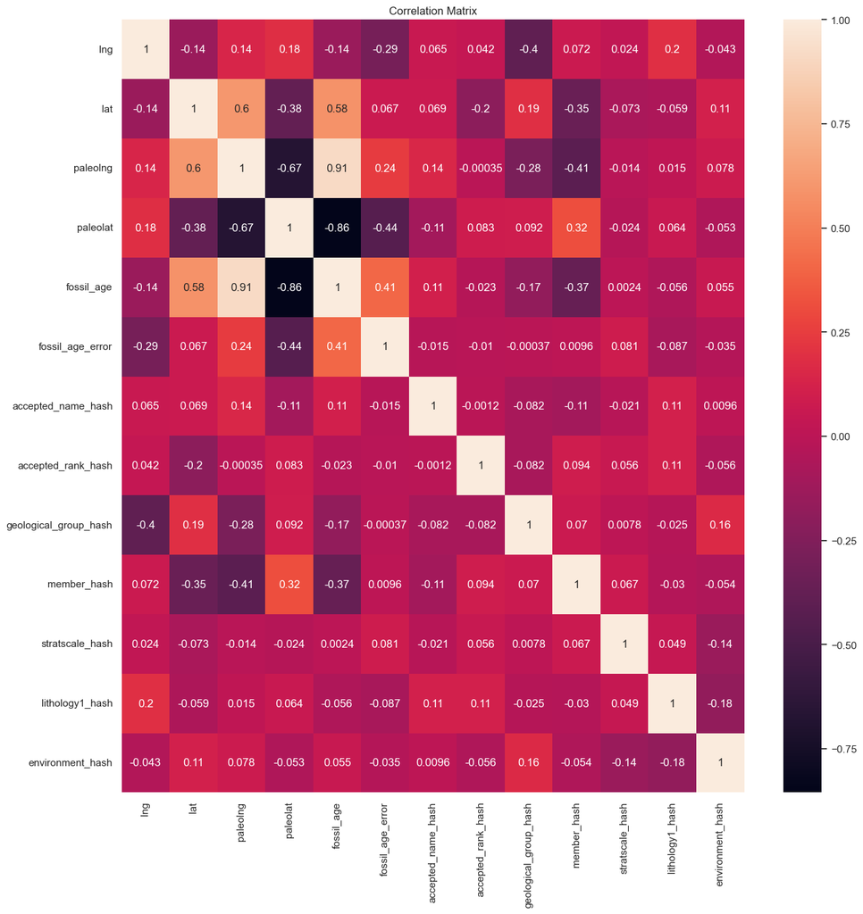

```python
from IPython.display import display, HTML
import seaborn as sns

# plot the correlation matrix

plt.figure(figsize=(20,15))
vars_to_use = df_imputed.columns # use all the columns

cmap = sns.set(style="darkgrid") # one of the many styles to plot using

f, ax = plt.subplots(figsize=(15, 15))
sns.heatmap(df_imputed[vars_to_use].corr(), cmap=cmap, annot=True)
plt.title('Correlation Matrix')
plt.show()
```

We also tried to see if there was a relationship between the name of the fossil and the age, but due to how many different types of fossils there are, it was difficult to find any connection between the variables and decided to not look into this further.

```python
#display(df_imputed.groupby("accepted_name_hash")["fossil_age"].describe())
```

```python
# We are using non-imputed data here
#plt.figure(figsize=(40,30))
#ax = sns.barplot(x="accepted_name", y="fossil_age", data=df_unhashed)
#ax.set_xticklabels(ax.get_xticklabels(), rotation=40, ha="right")
#plt.title('Fossil Age vs. Accepted Name')
#plt.show()
```

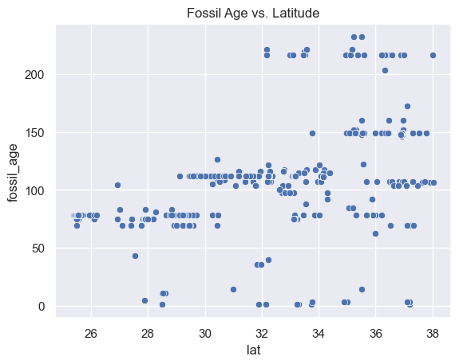

```python
sns.scatterplot(x="lat", y="fossil_age", data=df_imputed)
plt.title('Fossil Age vs. Latitude')
plt.show()
```

We first decided to explore how latitude affected fossil age. At first glance, there appears to be strange lines of correlation. For latitudes between 26 and 30, fossil age is concentrated around 75 million. These clusters can be seen throughout the scatterplot, which showed us that the latitude where the fossil was found does correlate to the fossil age, we are just not sure how yet.

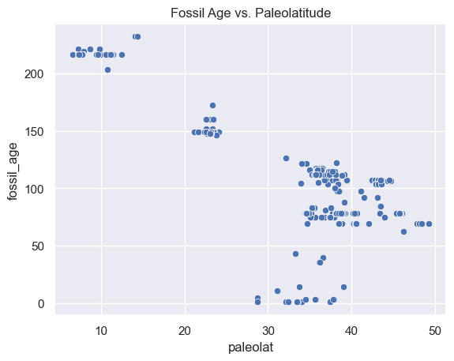

```python
sns.scatterplot(x="paleolat", y="fossil_age", data=df_imputed)
plt.title('Fossil Age vs. Paleolatitude')
plt.show()
```

Creating the same graph with paleolatitude instead of latitude yields a very similar but more concentrated result. We see the same "horizontal" correlation clusters that we saw in the previous scatterplot, but the groups in this graph are much closer together with much less data in between the grouping. This shows that the paleolatitude variable is likely more accurate than the lattitude variable in determining the fossil age, but more investigation is still required.

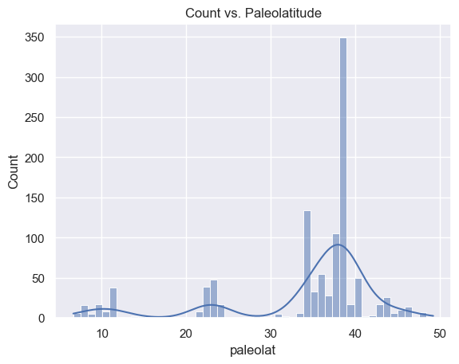

```python
sns.histplot(df_imputed["paleolat"], bins = 50, kde=True)
plt.title('Count vs. Paleolatitude')
plt.show()
```

The kernsel density estimation of paleolatitude confirms what we observed in the previous scatterplot, the distribution is not normal and is instead clustered around 3 main intervals.

Now that we have a baseline understanding of how paleolatitude and latitude affect fossil age, we wanted to explore the correlation between geological group and the other variables.

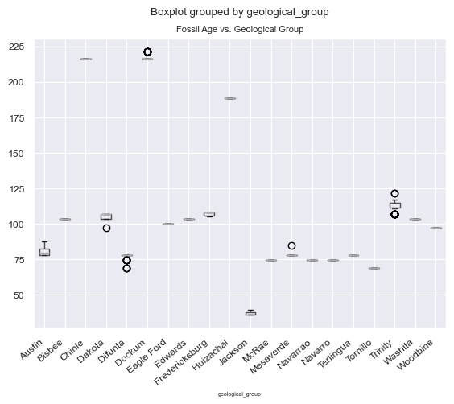

```python
# We are using non-imputed data here
sns.set_context("paper", rc={"font.size":8,"axes.titlesize":8,"axes.labelsize":5})
ax = df_unhashed.boxplot(column='fossil_age', by = 'geological_group') # group by class
ax.set_xticklabels(ax.get_xticklabels(), rotation=40, ha="right")
plt.ylabel('')
plt.title('Fossil Age vs. Geological Group')
plt.show()
```

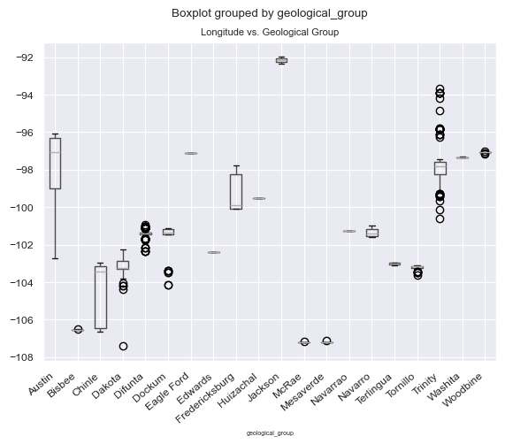

```python
# We are using non-imputed data here
sns.set_context("paper", rc={"font.size":8,"axes.titlesize":8,"axes.labelsize":5})
ax = df_unhashed.boxplot(column='lng', by = 'geological_group') # group by class
ax.set_xticklabels(ax.get_xticklabels(), rotation=40, ha="right")
plt.ylabel('')
plt.title('Longitude vs. Geological Group')
plt.show()
```

These graphs definitely point us in the right direction: locational data seems to be the most important in determining the fossil's age. However, these visualizations still leave us with a lot of questions in determining the best possible algorithm for determining fossil age.

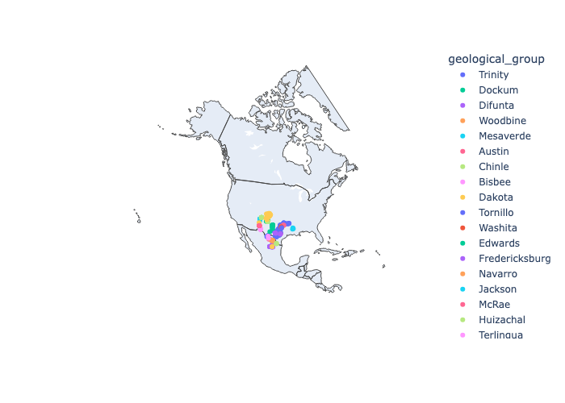

```python
import kaleido
await kaleido.get_chrome()
from plotly import express as px
from plotly import io as pio
pio.renderers.default = 'png'
fig = px.scatter_geo(df_unhashed, lat="lat", lon="lng", color="geological_group",
                    scope="north america")
fig.show()
```

After plotting the geographic group in relation to latitude and longitude, we can see that we were correct in assuming the correlation is stronger than what the boxplots initially showed. The geographic groups are highly condensed and result in the fossils within those groups being located very close to each other.

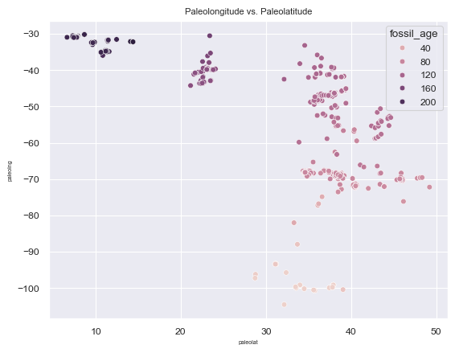

```python
sns.scatterplot(x="paleolat", y="paleolng", hue="fossil_age", data=df_imputed)
plt.title('Paleolongitude vs. Paleolatitude')
plt.show()
```

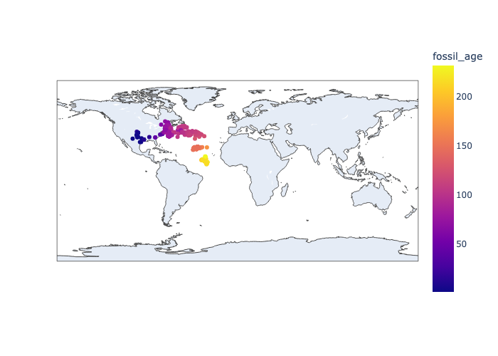

```python
fig = px.scatter_geo(df_imputed, lat="paleolat", lon="paleolng", color="fossil_age",
                    scope="world")
fig.show()
```

We were able to plot paleolatitude and paleolongitude against fossil age and found a very clear correlation between the groups. Fossils around the location of (-30,10) resulted in a fossil age of 200 million years, those around (-40,20) result in an age of 160 million years, etc. We thought plotting them over a current map of the world would be helpful, and it was. You can clearly see that fossils are in very specific clusters based on age and location. Therefore, the location of the fossil based on paleolat and paleolng has a direct correlation on how old the fossil is.

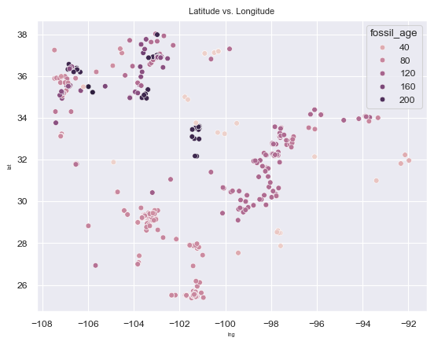

```python
sns.scatterplot(x="lng", y="lat", hue="fossil_age", data=df_imputed)
plt.title('Latitude vs. Longitude')
plt.show()
```

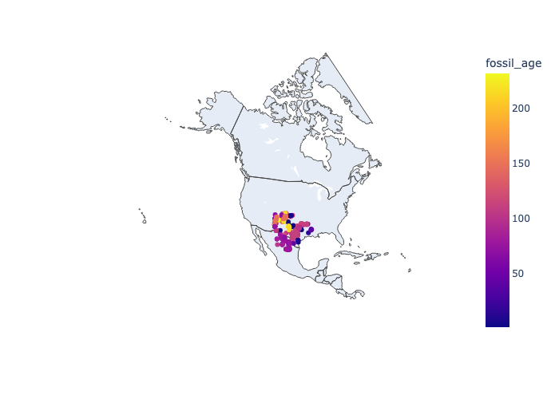

```python
fig = px.scatter_geo(df_imputed, lat="lat", lon="lng", color="fossil_age",
                    scope="north america")
fig.show()
```

We did the same thing with latitude and longitude, and found similar groupings. We can clearly see fossils that are 80 or 120 million years old are clustered faily tightly around the same latitudes and longitudes. However, the rest of the fossil ages are much less clustered and provide less valuable correlation than with the paleolatitude and longitude graph. This is shown on the graph of the same variables over a map of the world. There are many fossils around 100 million years old clustered around Central Texas, and many of the newer fossils clustered around Northern Mexico. This information is highly valuable demonstrating that geographic clustering can be useful in determining a fossil's age.

## Result Limitations

Due to the limitations of our study in selecting from a specific longitude and latitude range, it is clear that in our filtered portion of the dataset, the paleolatitude and paleolongitude have an exaggerated correlation to the fossil age. Nevertheless, in the full dataset with samples from the whole world, one would still be able to observe this result even more strongly given the current latitude and longitude are also known, as the difference between them is a direct proxy for age. Furthermore, in the full dataset, location-based correlation would be present in either set of variables for climate-related reasons. For instance, land animals such as dinosaurs would not be present in the middle of the ocean.

In regards to categorical variables that we chose to preserve, the choice to use a hash function over one hot encoding may have affected results. Unrelated items may have had numerically similar or potentially even colliding hash functions, and the hash may impose a false order providing the false impression of correlation coefficients that in fact are meaningless and cannot be analyzed.

The imputation of a large number of values in some variables may also have created false results that would need to be further checked against the original dataset.